# WiSTEM and WiENG 2023 - 2024

Student Entry Form (Pre / Post Analyses)

# Background

**WiSTEM:** In total, there were 15 overall WiSTEM meetings held throughout the 2023-2024 academic school year. There were 14 meetings with attendance data and 14 meetings with exit slip data (January 18th, 2024 is missing).

**WiENG:** In total, there were 29 overall WiENG meetings held throughout the 2023-2024 academic school year. There were 26 meetings with attendance data and 23 meetings with exit slip data. Some of these overlap in missing both attendance and exit slip data.

**Distribution:** As can be seen in the table below, there were a total of 70 student forms obtained for the Pre-Test while there were 93 student forms obtained for the Post-Test. There is a large discrepancy of 23 more forms being filled out by the end of the year, but the general trend can still be identified. These forms were either filled out during the original WiSTEM meetings (where a majority of them were) while some were filled out during some WiENG meetings.

Distribution of Pre and Post Forms

| Survey Type | Number of Forms | Proportion | Percent |
| --- | --- | --- | --- |
| Post | 93 | 0.5705521 | 57.05521 |
| Pre | 70 | 0.4294479 | 42.94479 |

# Career Analysis

## Career Amount

**Question:** List up to ten (10) STE(A)M career or job possibilities.

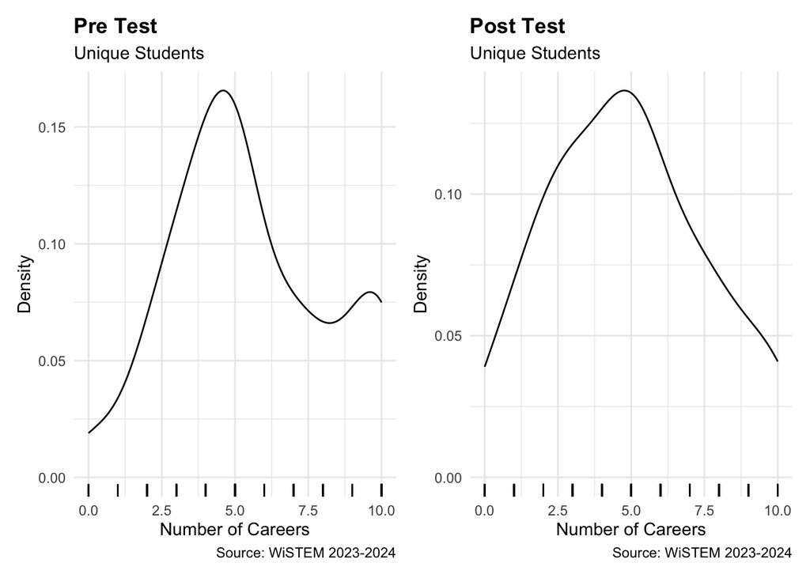

**Tables for Career Amount Analysis**

Comparing Statistical Summaries of Career Amounts

[output not shown]

Comparing 0 and 10 Career Amounts

| Type | Number of Careers | Proportion | Percent |
| --- | --- | --- | --- |
| pre | 0 | 0.0285714 | 2.857143 |
| post | 0 | 0.0430108 | 4.301075 |
| pre | 10 | 0.1285714 | 12.857143 |
| post | 10 | 0.0645161 | 6.451613 |

## Most and Least Popular Careers

**Pre Test: Most and Least Common**

**Most Common Careers in the Pre-Test**

Most Common Career Chosen in Pre Test

| Type | Career | Count | Proportion | Percent |
| --- | --- | --- | --- | --- |
| pre | Engineer | 34 | 0.0885417 | 8.854167 |
| pre | Doctor | 31 | 0.0807292 | 8.072917 |
| pre | Chemist | 27 | 0.0703125 | 7.031250 |
| pre | Mathematician | 18 | 0.0468750 | 4.687500 |
| pre | Physicist | 18 | 0.0468750 | 4.687500 |
| pre | Biologist | 16 | 0.0416667 | 4.166667 |
| pre | Architect | 13 | 0.0338542 | 3.385417 |
| pre | Nurse | 12 | 0.0312500 | 3.125000 |
| pre | Astronomer | 10 | 0.0260417 | 2.604167 |
| pre | Biomedical Engineer | 10 | 0.0260417 | 2.604167 |

**Least Common Careers in the Pre-Test**

```
Careers that were chosen only once:
```

```
 [1] "App Programmer"       "Architecture"         "Astrophysicist"
 [4] "Athlete"              "Biotechnician"        "Cardiac Surgeon"
 [7] "Cardiologist"         "Data Scientist"       "Dentist"
[10] "Engineeer"            "Manager"              "Material Engineer"
[13] "Math Teacher"         "Mechanic"             "Mechanical Engineeer"
[16] "Meterologist"         "Neural Engineer"      "Neurobiologist"
[19] "Neurologist"          "Neuropsychologist"    "Neurosurgeon"
[22] "Nnurse"               "Nuclear Engineer"     "Orthopedic Surgeon"
[25] "Pharmacist"           "Physical Therapist"   "Physicians Assistant"
[28] "Physiologist"         "Robotics Engineer"    "Rocket Scientist"
[31] "Science Teacher"      "Software Engineer"    "Statistician"
[34] "Systems Engineer"     "Techniciain"
```

```
Careers that were chosen only two or three times:
```

```
 [1] "Biochemical Engineer" "Chemical Engineer"    "Civil Engineer"
 [4] "Ecologist"            "Forensic Scientist"   "Geologist"
 [7] "Microbiologist"       "OB-GYN"               "Physician"
[10] "Public Health Worker" "Radiologist"          "Accountant"
[13] "Aerospace Engineer"   "Anesthesiologist"     "Biochemist"
[16] "Electrician"          "Geneticist"           "Materials Engineer"
[19] "Pediatrician"         "Programmer"           "Veterinarian"
```

**Post Test: Most and Least Common**

**Most Common Careers in the Post-Test**

Most Common Career Chosen in Post Test

| Type | Career | Count | Proportion | Percent |
| --- | --- | --- | --- | --- |
| post | Engineer | 44 | 0.0979955 | 9.799555 |
| post | Chemist | 37 | 0.0824053 | 8.240535 |
| post | Doctor | 29 | 0.0645880 | 6.458797 |
| post | Biologist | 26 | 0.0579065 | 5.790646 |
| post | Mathematician | 19 | 0.0423163 | 4.231626 |
| post | Mechanical Engineer | 15 | 0.0334076 | 3.340757 |
| post | Biomedical Engineer | 13 | 0.0289532 | 2.895323 |
| post | Computer Scientist | 13 | 0.0289532 | 2.895323 |
| post | Chemical Engineer | 12 | 0.0267261 | 2.672606 |
| post | Architect | 11 | 0.0244989 | 2.449889 |

**Least Common Careers in the Post-Test**

```
Careers that were chosen only once:
```

```
 [1] "Accountant"                 "Animator"
 [3] "Anthropologist"             "Architectural Engineer"
 [5] "Architecture"               "Biochemical Engineer"
 [7] "Biochemistry"               "Bioethicist"
 [9] "Biomechanist"               "Biophysicist"
[11] "Business Manager"           "Chemical Physicist"
[13] "Climate Change Scientist"   "Computer Engineer"
[15] "Cosmetics Engineer"         "Dermatologist"
[17] "Environmental Scientist"    "FDA Tester"
[19] "Fashion Designer"           "Forensics Psychologist"
[21] "Forensics Scientist"        "Genetic Counselor"
[23] "IT"                         "Industrial Engineer"
[25] "Mechanic"                   "Medical Engineer"
[27] "Microbiologist"             "Nuclear Physicist"
[29] "Orthopedic Surgeon"         "Orthopedic Technician"
[31] "Patents Lawyer"             "Roboticist"
[33] "Robotics Engineer"          "Software Manager"
[35] "Statistician"               "Structural Engineer"
[37] "Sustainability Coordinator" "Technician"
[39] "Web Developer"              "Zoologist"
```

```
Careers that were chosen only two or three times:
```

```
 [1] "Astronomer"             "Electrician"            "Geneticist"
 [4] "Neurologist"            "Nuclear Engineer"       "Pediatrician"
 [7] "Physical Therapist"     "Physician"              "Psychiatrist"
[10] "Psychologist"           "Software Developer"     "Theoretical Physicist"
[13] "X-ray Technician"       "Astronaut"              "Dentist"
[16] "Electrical Engineer"    "Environmental Engineer" "Material Engineer"
[19] "Technologist"           "Traffic Controller"
```

**Difference Between Pre and Post-Test Career Choices**

**Change in Careers**

```
New careers present in the pre-test, but not post-test:
```

```
 [1] "Anesthesiologist"     "App Programmer"       "Athlete"
 [4] "Biotechnician"        "Cardiac Surgeon"      "Cardiologist"
 [7] "Computer Programmer"  "Ecologist"            "Engineeer"
[10] "Forensic Scientist"   "Geologist"            "Manager"
[13] "Materials Engineer"   "Mechanical Engineeer" "Meterologist"
[16] "Neural Engineer"      "Neurobiologist"       "Neuropsychologist"
[19] "Neurosurgeon"         "Nnurse"               "Pharmacist"
[22] "Physicians Assistant" "Physiologist"         "Public Health Worker"
[25] "Rocket Scientist"     "Systems Engineer"     "Teacher"
[28] "Techniciain"
```

```
Careers present in the post-test, but not pre-test:
```

```
 [1] "Animator"                   "Anthropologist"
 [3] "Architectural Engineer"     "Biochemistry"
 [5] "Bioethicist"                "Biomechanist"
 [7] "Biophysicist"               "Business Manager"
 [9] "Chemical Physicist"         "Climate Change Scientist"
[11] "Computer Engineer"          "Cosmetics Engineer"
[13] "Dermatologist"              "Electrical Engineer"
[15] "FDA Tester"                 "Fashion Designer"
[17] "Forensics Psychologist"     "Forensics Scientist"
[19] "Genetic Counselor"          "Graphic Designer"
[21] "Medical Engineer"           "Nuclear Physicist"
[23] "Orthopedic Technician"      "Patents Lawyer"
[25] "Professor"                  "Psychiatrist"
[27] "Roboticist"                 "Software Developer"
[29] "Software Manager"           "Structural Engineer"
[31] "Sustainability Coordinator" "Technologist"
[33] "Theoretical Physicist"      "Traffic Controller"
[35] "Web Developer"              "X-ray Technician"
[37] "Zoologist"
```

**Constant Careers**

```
The same careers present in both the pre and post-tests:
```

```
 [1] "Accountant"              "Aerospace Engineer"
 [3] "Architect"               "Architecture"
 [5] "Artist"                  "Astronaut"
 [7] "Astronomer"              "Astrophysicist"
 [9] "Biochemical Engineer"    "Biochemist"
[11] "Bioengineer"             "Biologist"
[13] "Biomedical Engineer"     "Chemical Engineer"
[15] "Chemist"                 "Civil Engineer"
[17] "Computer Scientist"      "Data Scientist"
[19] "Dentist"                 "Doctor"
[21] "Electrician"             "Engineer"
[23] "Environmental Engineer"  "Environmental Scientist"
[25] "Geneticist"              "IT"
[27] "Industrial Engineer"     "Marine Biologist"
[29] "Material Engineer"       "Math Teacher"
[31] "Mathematician"           "Mechanic"
[33] "Mechanical Engineer"     "Microbiologist"
[35] "Neurologist"             "Neuroscientist"
[37] "Nuclear Engineer"        "Nurse"
[39] "OB-GYN"                  "Orthopedic Surgeon"
[41] "Pediatrician"            "Physical Therapist"
[43] "Physician"               "Physicist"
[45] "Programmer"              "Psychologist"
[47] "Radiologist"             "Researcher"
[49] "Robotics Engineer"       "Science Teacher"
[51] "Scientist"               "Software Engineer"
[53] "Statistician"            "Surgeon"
[55] "Technician"              "Veterinarian"
```

# Likert Scale Questions

## Question 1

**Question:** If I work hard to solve a problem, I’ll find the answer.

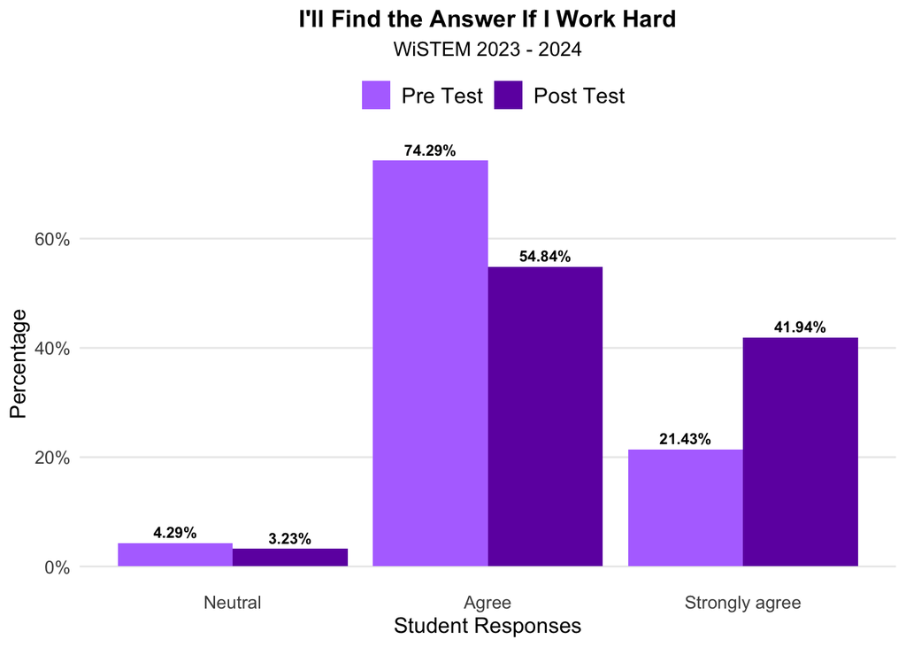

**Table for Work Hard**

Pre and Post Percent Distribution for work_hard

| test | Agree | Neutral | Strongly agree |
| --- | --- | --- | --- |
| pre | 74.28571 | 4.285714 | 21.42857 |
| post | 54.83871 | 3.225807 | 41.93548 |

## Question 2

**Question:** I am confident in my ability to apply prior knowledge to succeed in new projects.

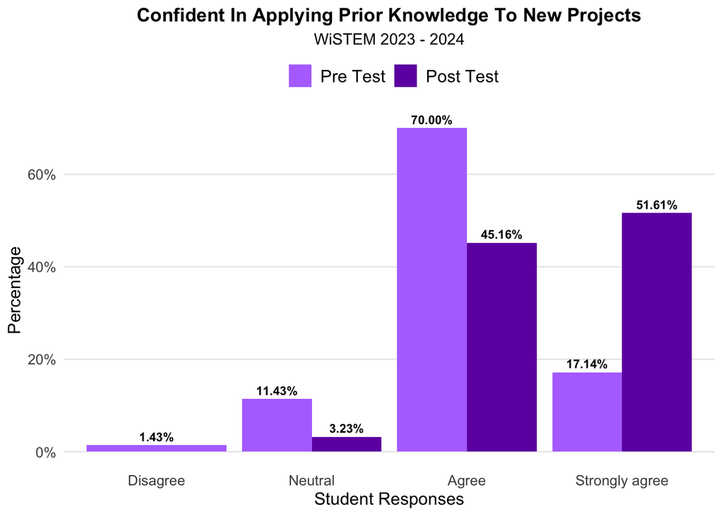

**Table for Knowledge**

Pre and Post Percent Distribution for knowledge

| test | Agree | Disagree | Neutral | Strongly agree |
| --- | --- | --- | --- | --- |
| pre | 70.00000 | 1.428571 | 11.428571 | 17.14286 |
| post | 45.16129 | NA | 3.225807 | 51.61290 |

## Question 3

**Question:** I feel confident in my ability to do well in STE(A)M courses.

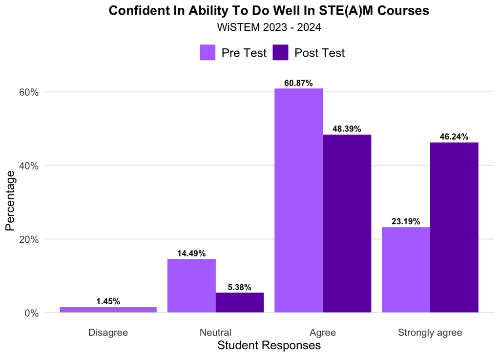

**Table for Courses**

Pre and Post Percent Distribution for courses

| test | Agree | Disagree | Neutral | Strongly agree |
| --- | --- | --- | --- | --- |
| pre | 60.86957 | 1.449275 | 14.492754 | 23.18841 |
| post | 48.38710 | NA | 5.376344 | 46.23656 |

## Question 4

**Question:** I think I could be successful in a STE(A)M career.

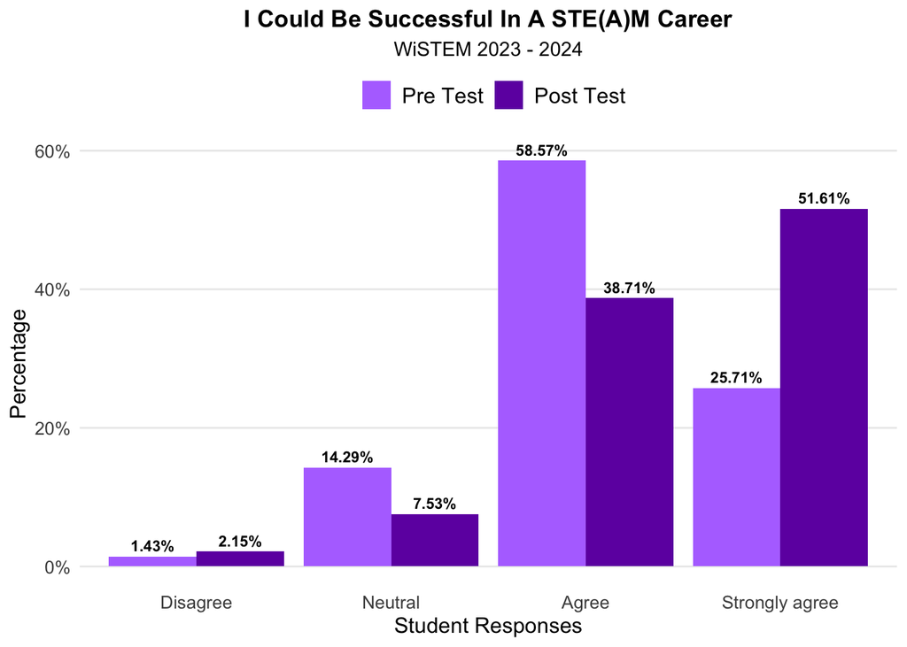

**Table for Successful**

Pre and Post Percent Distribution for succesful

| test | Agree | Disagree | Neutral | Strongly agree |
| --- | --- | --- | --- | --- |
| pre | 58.57143 | 1.428571 | 14.285714 | 25.71429 |
| post | 38.70968 | 2.150538 | 7.526882 | 51.61290 |

## Question 5

**Question:** People who work in a STE(A)M field can solve important problems.

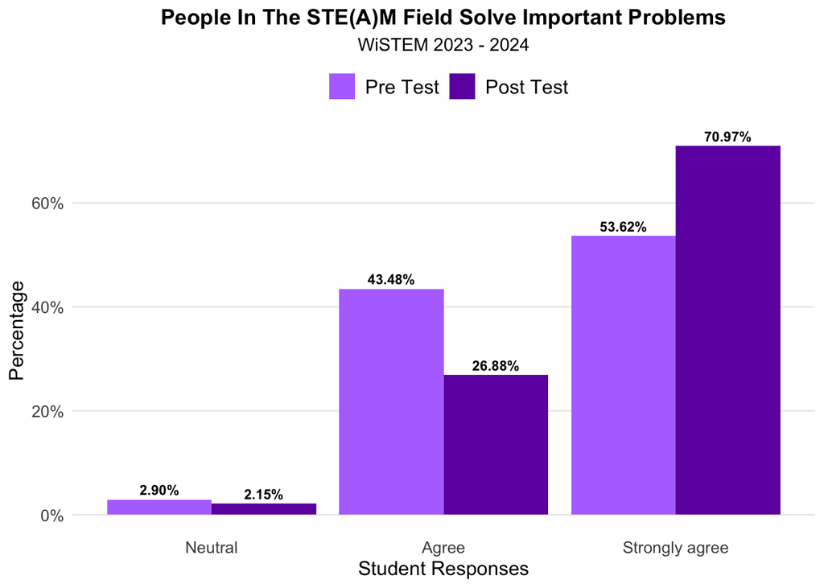

**Table for Important**

Pre and Post Percent Distribution for important

| test | Agree | Neutral | Strongly agree |
| --- | --- | --- | --- |
| pre | 43.47826 | 2.898551 | 53.62319 |
| post | 26.88172 | 2.150538 | 70.96774 |

## Question 6

**Question:** I am a member of a STE(A)M community.

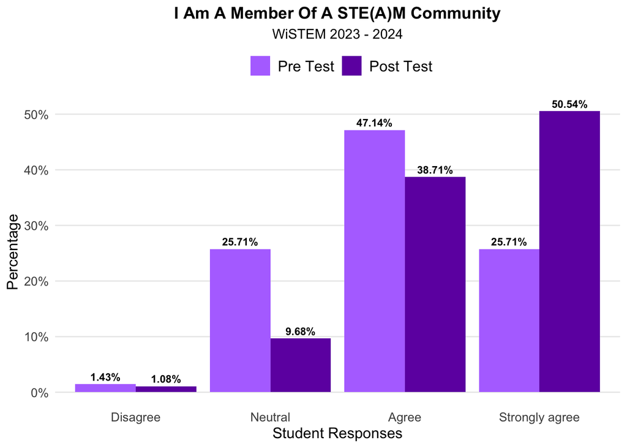

**Table for Member**

Pre and Post Percent Distribution for member

| test | Agree | Disagree | Neutral | Strongly agree |
| --- | --- | --- | --- | --- |
| pre | 47.14286 | 1.428571 | 25.714286 | 25.71429 |
| post | 38.70968 | 1.075269 | 9.677419 | 50.53763 |

## Question 7

**Question:** I think a career in STE(A)M may be a good fit for me.

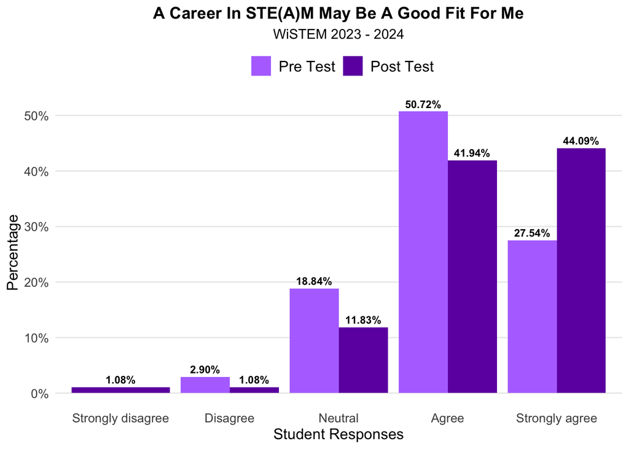

**Table for Career**

Pre and Post Percent Distribution for career

| test | Agree | Disagree | Neutral | Strongly agree | Strongly disagree |
| --- | --- | --- | --- | --- | --- |
| pre | 50.72464 | 2.898551 | 18.84058 | 27.53623 | NA |
| post | 41.93548 | 1.075269 | 11.82796 | 44.08602 | 1.075269 |

## Question 8

**Question:** “Future STE(A)M professional” as part of my identity is important to me.

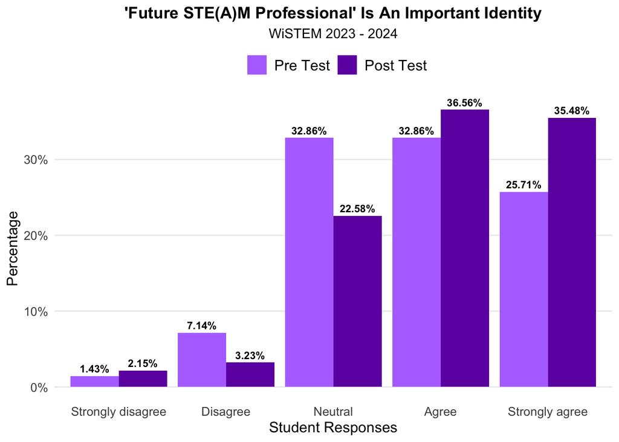

**Table for Identity**

Pre and Post Percent Distribution for identity

| test | Agree | Disagree | Neutral | Strongly agree | Strongly disagree |
| --- | --- | --- | --- | --- | --- |
| pre | 32.85714 | 7.142857 | 32.85714 | 25.71429 | 1.428571 |
| post | 36.55914 | 3.225807 | 22.58065 | 35.48387 | 2.150538 |

## Question 9

**Question:** If I entered a STE(A)M career, I could make a meaningful contribution to society.

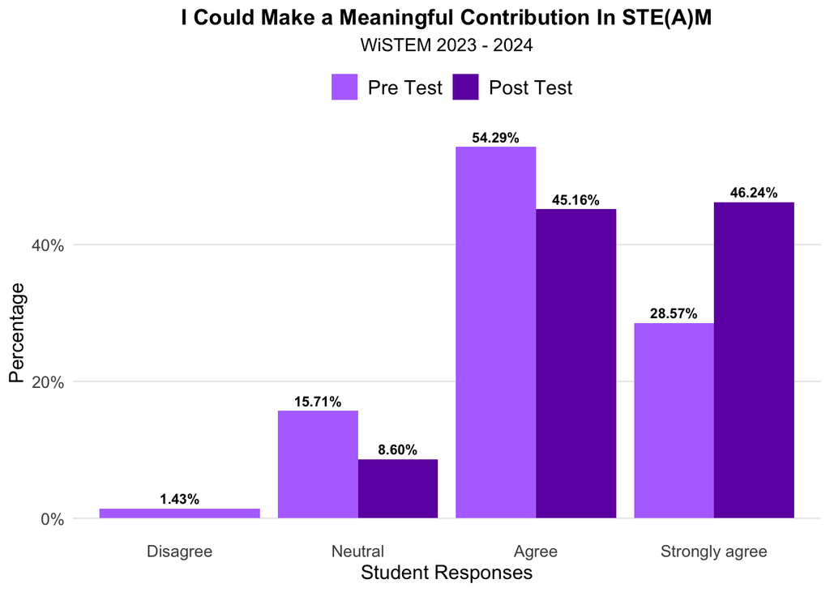

**Table for Meaningful**

Pre and Post Percent Distribution for meaningful

| test | Agree | Disagree | Neutral | Strongly agree |
| --- | --- | --- | --- | --- |
| pre | 54.28571 | 1.428571 | 15.714286 | 28.57143 |
| post | 45.16129 | NA | 8.602151 | 46.23656 |

## Question 10

**Question:** I understand what everyday STE(A)M work is like.

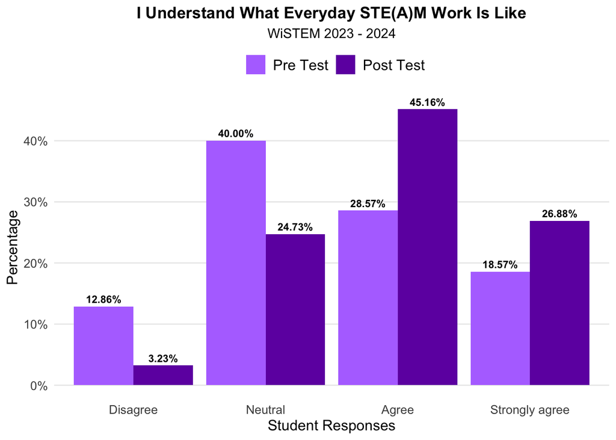

**Table for Everyday**

Pre and Post Percent Distribution for everyday

| test | Agree | Disagree | Neutral | Strongly agree |
| --- | --- | --- | --- | --- |
| pre | 28.57143 | 12.857143 | 40.00000 | 18.57143 |
| post | 45.16129 | 3.225807 | 24.73118 | 26.88172 |